# Assignment 15: Writing a function - Conditional Statement

*How to do it?*:

- Open the Rmarkdown file of this assignment (link) in Rstudio.
- Right under each **question**, insert a code chunk (you can use the hotkey `Ctrl + Alt + I` to add a code chunk) and code the solution for the question.
- `Knit` the rmarkdown file (hotkey: `Ctrl + Alt + K`) to export an html.
- Publish the html file to your Githiub Page.

*Submission*: Submit the link on Github of the assignment to Canvas

#### NOTICE: Question 7, 8 and 9 are optional.

1. Write a function to calculate the age of a person. Give an example to test your function.
- Input: a number, x, (year born)
- Output: Print out “You are r age”. Where r is the age of the person, i.e. 2020 - x.

Hint: [Similar Function](https://bryantstats.github.io/math421/gganimate/17_writing_functions.html#42)

```r
age <- function(x)
{
  r = 2022 - x
  print(paste0('You are ', r, ' age'))
}

age(2000)
```

```
## [1] "You are 22 age"
```

2. Write the following function. Give an example to test your function.
- Input: a number
- Output: print out: “You input an even number!” if the number is event, or “You input an odd number!” otherwise.

Hint: [Similar Function](https://bryantstats.github.io/math421/gganimate/17_writing_functions.html#46)

```r
even_odd <- function(x)
{
  if(x %% 2 == 0)
  {
    print('You input an even number!')
  }
  else
  {
    print('you input an odd number!')
  }
}
even_odd(32)
```

```
## [1] "You input an even number!"
```

3. Write the following function. Give an example to test your function.
- Input: a numeric vector
- Output:
  - if the input vector has missing values: return the input vector with missing values replaced by mean
  - if the input vector has no missing value: return the same input vector

Hint: [Similar Function](https://bryantstats.github.io/math421/gganimate/17_writing_functions.html#50)

```r
library(tidyr)
library(tidyverse)
mean_missing <- function(x)
{
  if(is.numeric(x))
  {
    mean_of_x <- mean(x, na.rm=TRUE)
    x <- replace_na(x, mean_of_x)
  }
return(x)
}

df <- read_csv('titanic.csv')
subject <- mean_missing(df$Age)
mean(subject)
```

```
## [1] 29.69912
```

4. Write the following function. Give an example to test your function.
- Input: a vector x
- Output: The vector x where the missing values replaced by the mean (if x is numeric) or the mode (if x is non-numeric). If x does not have missing value, return the same vector x.

Hint: Use If-statement to combine the function in Question 3 and [this function](https://bryantstats.github.io/math421/gganimate/17_writing_functions.html#49)

```r
mode_missing <- function(x)
{
  if(!is.numeric(x))
  {
    mode_of_x <- names(sort(-table(x)))[1]
    x <- replace_na(x, mode_of_x)
  }
  else
  {
    mean_of_x <- mean(x, trim=0, na.rm=TRUE)
    x <- replace_na(x, mean_of_x)
  }
return(x)
}

df <- read_csv('titanic.csv')
subject <- mode_missing(df$Embarked)
max(subject)
```

```
## [1] "S"
```

5. Write the following function. Give examples to test your function.
- Input: A data frame of two variables x and y
- Output:
  - A boxplot of x by y if x is numeric and y is non-numeric
  - A boxplot of y by x if y is numeric and x is non-numeric
  - print out ‘This function cannot visualize your data’ otherwise

Hint:

- [Similar Function](https://bryantstats.github.io/math421/gganimate/17_writing_functions.html#53)
- You can refer to this slide to plot a boxplot: https://bryantstats.github.io/math421/slides/6_viz.html#36

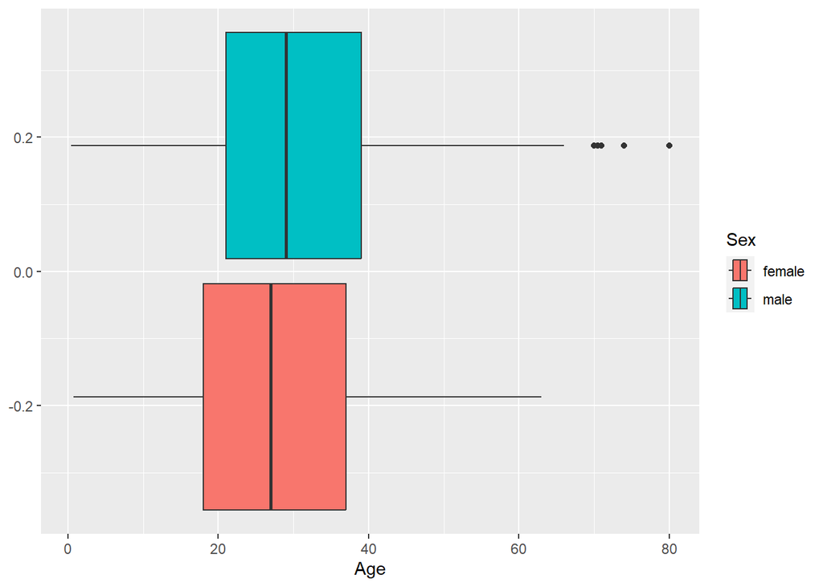

```r
viz <- function(df)
{
  if(is.numeric(df[[1]])&(!is.numeric(df[[2]])))
  {
    df %>% ggplot(aes(x = df[[1]], y = df[[2]]))+
      geom_boxplot()+
      labs(x = names(df)[1], y = names(df)[2])
  }
  else if ((!is.numeric(df[[1]])&is.numeric(df[[2]])))
  {
    df %>% ggplot(aes(x = df[[2]], fill = df[[1]]))+
      geom_boxplot()+
      labs(x = names(df)[2], fill = names(df)[1])
  }
  else
  {
    print('This function cannot visualize your data.')
  }
}

plot1 <- df %>% select(Sex, Age)
viz(plot1)
```

6. Combine the function in Question 5 and the function in this example ([Link](https://bryantstats.github.io/math421/gganimate/17_writing_functions.html#53)) to have a function that can plot all possible cases (2 categorical, 2 numeric, 1 numeric and 1 categorical).

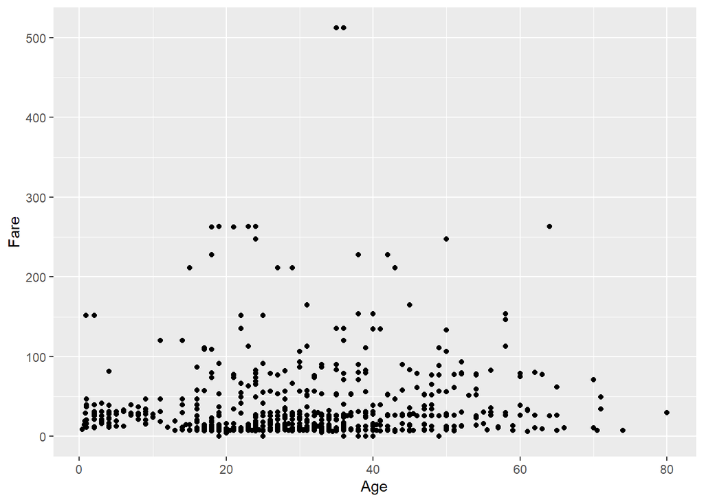

```r
viz <- function(df)
{
  if(is.numeric(df[[1]])&is.numeric(df[[2]]))
  {
    df %>% ggplot(aes(x = df[[1]], y = df[[2]]))+
      geom_point()+
      labs(x = names(df)[1], y = names(df)[2])
  }
  else if (!(is.numeric(df[[1]])|is.numeric(df[[2]])))
  {
    df %>% ggplot(aes(x = df[[1]], fill = df[[2]]))+
      geom_bar(position = 'dodge')+
      labs(x = names(df)[1], fill = names(df)[2])
  }
  else if(is.numeric(df[[1]])&(!is.numeric(df[[2]])))
  {
    df %>% ggplot(aes(x = df[[1]], y = df[[2]]))+
      geom_boxplot()+
      labs(x = names(df)[1], y = names(df)[2])
  }
  else if ((!is.numeric(df[[1]])&is.numeric(df[[2]])))
  {
    df %>% ggplot(aes(x = df[[2]], fill = df[[1]]))+
      geom_boxplot()+
      labs(x = names(df)[2], fill = names(df)[1])
  }
  else
  {
    print('This function cannot visualize your data.')
  }
}

plot2 <- df %>% select(Age, Fare)
viz(plot2)
```

#### NOTICE: Question 7, 8 and 9 are optional.

7. Write the following function. Give examples to test your function.
- Input:
  - input_data: a clean data frame with a variable name `target`. The `target` variable is also binary.
  - train_percent: a number presenting a proportion of training data. The default train_percent is .8
- Output: the accuracy of the decision model `rpart` where the training data is train_percent.
8. Write the following function. Give examples to test your function.
- Input:
  - input_data: a clean data frame with a variable name `target`. The `target` variable is also binary.
  - train_percent: a number presenting a proportion of training data. The default train_percent is .8
- Output: the plot of variable important by random forest trained by caret.
9. Write the following function. Give examples to test your function.
- Input:
  - a data frame that has a text column
  - the name of the text column in the data
- Output: the word cloud plot of the text column

Sample codes

- [Word Cloud codes](https://bryantstats.github.io/math421/assignments/text_mining_sample_codes2.html#Total_Word_Cloud)
- [A similar function](https://bryantstats.github.io/math421/gganimate/17_writing_functions.html#10)